# **Existe diferença significante de atrasos de voo entre duas companhia aéreas?**

Rodolfo R. Terra | Cientista de Dados

# **Sumário**

…

1.**Coletando os Dados**

2.**Exploração de Dados**

3.**Construindo o Dataset**

4.**Criação de Amostragem**

5.**Intervalo de Confiança**

6.**Gráfico dos Intervalos de Confiança**

7.**Criação do Teste de Hipótese**

7.1.**Teste t**

7.2.**Valor p**

8.**Conclusão**

## **Definição do Problema de Negócio**

##### Para analisar se existe diferença de atraso de vôo entre a companhia utilizaremos teste de hipósete de um conjunto de dados que possui 336,776 observações e 19 variáveis, chamado flights", que demonstram dados pontuais de todos os voos que partiram de Nova York em 2013. Dentre estas companhia escolheremos duas companhias: Delta Airlines (DL) e a United Airlines (UA).

### **Etapa 1 - Coletando os Dados**

##### Aqui está a coleta de dados.

```r
# Coletando dados
library('ggplot2')
library('dplyr')
library('nycflights13')
head(flights)
```

| year | month | day | dep_time | sched_dep_time | dep_delay | arr_time | sched_arr_time | arr_delay | carrier | flight | tailnum | origin | dest | air_time | distance | hour | minute | time_hour |
| --- | --- | --- | --- | --- | --- | --- | --- | --- | --- | --- | --- | --- | --- | --- | --- | --- | --- | --- |
| 2013 | 1 | 1 | 517 | 515 | 2 | 830 | 819 | 11 | UA | 1545 | N14228 | EWR | IAH | 227 | 1400 | 5 | 15 | 2013-01-01 05:00:00 |
| 2013 | 1 | 1 | 533 | 529 | 4 | 850 | 830 | 20 | UA | 1714 | N24211 | LGA | IAH | 227 | 1416 | 5 | 29 | 2013-01-01 05:00:00 |
| 2013 | 1 | 1 | 542 | 540 | 2 | 923 | 850 | 33 | AA | 1141 | N619AA | JFK | MIA | 160 | 1089 | 5 | 40 | 2013-01-01 05:00:00 |
| 2013 | 1 | 1 | 544 | 545 | -1 | 1004 | 1022 | -18 | B6 | 725 | N804JB | JFK | BQN | 183 | 1576 | 5 | 45 | 2013-01-01 05:00:00 |
| 2013 | 1 | 1 | 554 | 600 | -6 | 812 | 837 | -25 | DL | 461 | N668DN | LGA | ATL | 116 | 762 | 6 | 0 | 2013-01-01 06:00:00 |
| 2013 | 1 | 1 | 554 | 558 | -4 | 740 | 728 | 12 | UA | 1696 | N39463 | EWR | ORD | 150 | 719 | 5 | 58 | 2013-01-01 05:00:00 |

### **Etapa 2 - Exploração dos Dados**

```r
head(flights)
```

| year | month | day | dep_time | sched_dep_time | dep_delay | arr_time | sched_arr_time | arr_delay | carrier | flight | tailnum | origin | dest | air_time | distance | hour | minute | time_hour |
| --- | --- | --- | --- | --- | --- | --- | --- | --- | --- | --- | --- | --- | --- | --- | --- | --- | --- | --- |
| 2013 | 1 | 1 | 517 | 515 | 2 | 830 | 819 | 11 | UA | 1545 | N14228 | EWR | IAH | 227 | 1400 | 5 | 15 | 2013-01-01 05:00:00 |
| 2013 | 1 | 1 | 533 | 529 | 4 | 850 | 830 | 20 | UA | 1714 | N24211 | LGA | IAH | 227 | 1416 | 5 | 29 | 2013-01-01 05:00:00 |
| 2013 | 1 | 1 | 542 | 540 | 2 | 923 | 850 | 33 | AA | 1141 | N619AA | JFK | MIA | 160 | 1089 | 5 | 40 | 2013-01-01 05:00:00 |
| 2013 | 1 | 1 | 544 | 545 | -1 | 1004 | 1022 | -18 | B6 | 725 | N804JB | JFK | BQN | 183 | 1576 | 5 | 45 | 2013-01-01 05:00:00 |
| 2013 | 1 | 1 | 554 | 600 | -6 | 812 | 837 | -25 | DL | 461 | N668DN | LGA | ATL | 116 | 762 | 6 | 0 | 2013-01-01 06:00:00 |
| 2013 | 1 | 1 | 554 | 558 | -4 | 740 | 728 | 12 | UA | 1696 | N39463 | EWR | ORD | 150 | 719 | 5 | 58 | 2013-01-01 05:00:00 |

```r
# Visualizando as variáveis
str(flights)
```

```
## Classes 'tbl_df', 'tbl' and 'data.frame':    336776 obs. of  19 variables:
##  $ year          : int  2013 2013 2013 2013 2013 2013 2013 2013 2013 2013 ...
##  $ month         : int  1 1 1 1 1 1 1 1 1 1 ...
##  $ day           : int  1 1 1 1 1 1 1 1 1 1 ...
##  $ dep_time      : int  517 533 542 544 554 554 555 557 557 558 ...
##  $ sched_dep_time: int  515 529 540 545 600 558 600 600 600 600 ...
##  $ dep_delay     : num  2 4 2 -1 -6 -4 -5 -3 -3 -2 ...
##  $ arr_time      : int  830 850 923 1004 812 740 913 709 838 753 ...
##  $ sched_arr_time: int  819 830 850 1022 837 728 854 723 846 745 ...
##  $ arr_delay     : num  11 20 33 -18 -25 12 19 -14 -8 8 ...
##  $ carrier       : chr  "UA" "UA" "AA" "B6" ...
##  $ flight        : int  1545 1714 1141 725 461 1696 507 5708 79 301 ...
##  $ tailnum       : chr  "N14228" "N24211" "N619AA" "N804JB" ...
##  $ origin        : chr  "EWR" "LGA" "JFK" "JFK" ...
##  $ dest          : chr  "IAH" "IAH" "MIA" "BQN" ...
##  $ air_time      : num  227 227 160 183 116 150 158 53 140 138 ...
##  $ distance      : num  1400 1416 1089 1576 762 ...
##  $ hour          : num  5 5 5 5 6 5 6 6 6 6 ...
##  $ minute        : num  15 29 40 45 0 58 0 0 0 0 ...
##  $ time_hour     : POSIXct, format: "2013-01-01 05:00:00" "2013-01-01 05:00:00" ...
```

### **Medidas de Tendência Central da Variável Numéricas**

```r
summary(flights$arr_delay)
```

```
##     Min.  1st Qu.   Median     Mean  3rd Qu.     Max.     NA's
##  -86.000  -17.000   -5.000    6.895   14.000 1272.000     9430
```

```r
# Tabela de contigêcia das linhas aéreas
table(flights$carrier)
```

```
##
##    9E    AA    AS    B6    DL    EV    F9    FL    HA    MQ    OO    UA    US
## 18460 32729   714 54635 48110 54173   685  3260   342 26397    32 58665 20536
##    VX    WN    YV
##  5162 12275   601
```

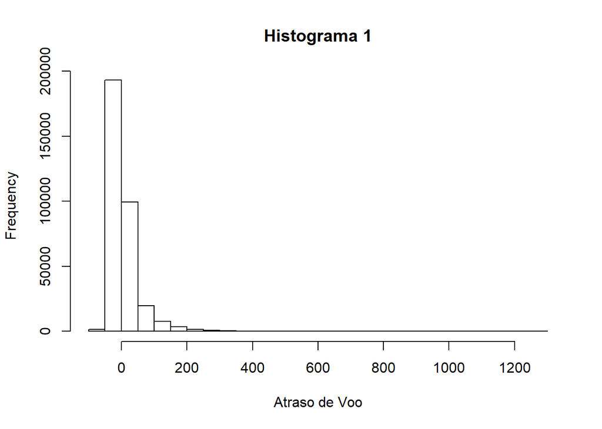

```r
#Histograma
hist(flights$arr_delay, main = 'Histograma 1', xlab = 'Atraso de Voo')
```

### **Etapa 3 - Construindo o Dataset**

##### Construção do dataset pop_data com os dados de voos das companhias aéreas UA (United Airlines) e DL (Delta Airlines). Contruiremos um dataset irá conter apenas duas colunas, nome da companhia e atraso nos voos de chegada. Será conssiderado este dataset como sendo nossa população de voos:

**Metodologia da formula:**

##### 1º eliminação de todos os dados na (Valores missing, não disponivel); 2º Filtro pela companhia aérea UA (United Airlines) e DL (Delta Airlines); 3º Filtro para retornar apenas os valores que forem igual ou maior a ‘Zero’. Os valores negativos serão descontiderádos;

```r
pop_data = na.omit(flights) %>%
  filter(carrier == 'UA' | carrier == 'DL', arr_delay >=0) %>%
  select(carrier, arr_delay) %>%
  group_by(carrier) %>%
  sample_n(17000) %>%
  ungroup()


head(pop_data)
```

| carrier | arr_delay |
| --- | --- |
| DL | 2 |
| DL | 6 |
| DL | 6 |
| DL | 95 |
| DL | 12 |
| DL | 39 |

```r
tail(pop_data)
```

| carrier | arr_delay |
| --- | --- |
| UA | 42 |
| UA | 234 |
| UA | 11 |
| UA | 2 |
| UA | 47 |
| UA | 71 |

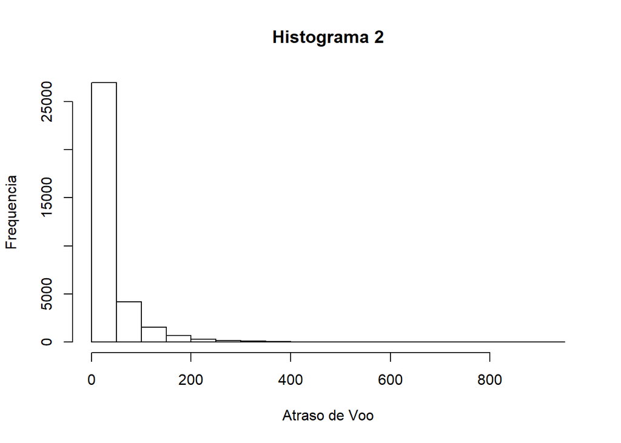

```r
hist(pop_data$arr_delay, main = 'Histograma 2', xlab = 'Atraso de Voo', ylab="Frequencia")
```

##### É importante observar que neste histograma removemos os valores negativos, pois temos como principal objetivo observar somente os atrasos de voos. Os valores no conjunto de dados que representam menores que zero seguinifica que o voo chegou a sei destido antes da data prevista, então não houve atraso.

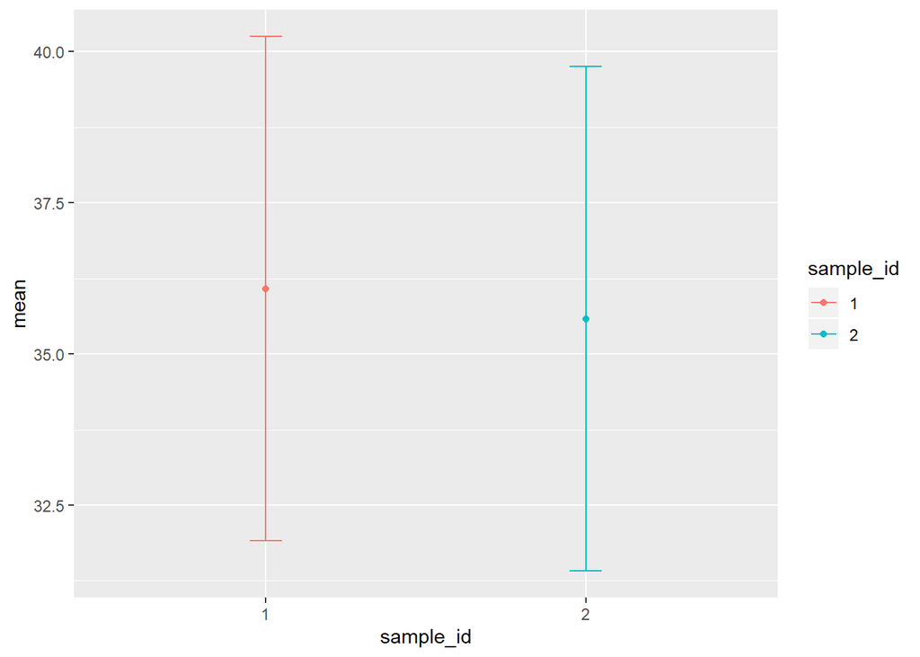